# Heirarchical Models

Simon Thornewill von Essen

4 2 2020

Get data

```r
dat <- read.table(file="cookies.dat", header=TRUE)
```

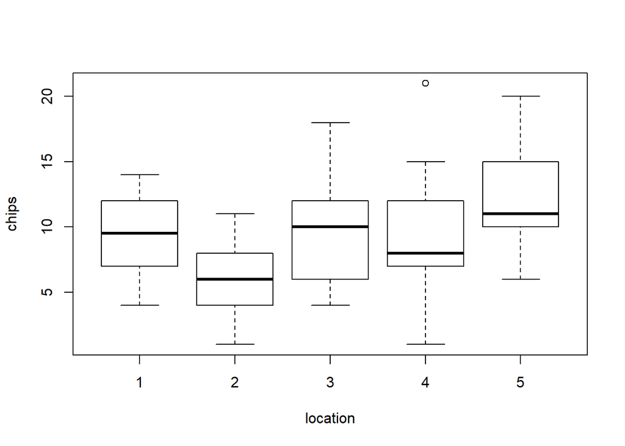

```r
boxplot(chips ~ location, data=dat)
```

## Setting priors

When it comes to prior models, we need to make sure to choose good values.

We can take a guess at priors and follow them down the heirarchical model to see where they lead.

Remember that the heirarchical model looks as follows:

$$y_{i, j} \sim Pois(\lambda_j), (i=1, ..., 30), (j=1,...,5) \\
\lambda_j |\alpha, \beta \sim Gamma(\alpha, \beta), (j=1,...,5) \\
\alpha \sim p(\alpha), \beta \sim p(\beta)$$

```r
n_sim <- 500

alpha_pri <- rexp(n_sim, rate=1.0/2.0)
beta_pri <- rexp(n_sim, rate=5.0)
```

Now that we have random values for alpha and beta, let’s have a look at what our values for lambda would look like.

```r
mu_pri <- alpha_pri / beta_pri
sig_pri <- sqrt(alpha_pri / beta_pri^2)

summary(mu_pri)
```

```
##     Min.  1st Qu.   Median     Mean  3rd Qu.     Max.
##    0.019    3.269    8.921   51.822   28.997 5421.759
```

```r
summary(sig_pri)
```

```
##      Min.   1st Qu.    Median      Mean   3rd Qu.      Max.
##    0.2348    3.3910    7.5298   31.2647   20.3207 3108.8460
```

We get a median with the expected number of chips per cookie, but it should be noted that the distribution is heavily right skewed, as we can see when comparing the median and the mean.

Now, let’s draw the lambdas

```r
lam_pri <- rgamma(n_sim, shape=alpha_pri, rate=beta_pri)

summary(lam_pri)
```

```
##     Min.  1st Qu.   Median     Mean  3rd Qu.     Max.
##    0.000    1.582    7.131   44.609   25.239 2628.464
```

So can see this carried forward. Note that if we wanted to reign the skewness in, we would tinker with our priors until we got something that we are happy with.

```r
y_pri <- rpois(n_sim, lam_pri)

summary(y_pri)
```

```
##    Min. 1st Qu.  Median    Mean 3rd Qu.    Max.
##    0.00    1.00    7.00   44.56   26.00 2640.00
```

If we wanted to try and recreate our dataset, we should just keep five of these lambda priors

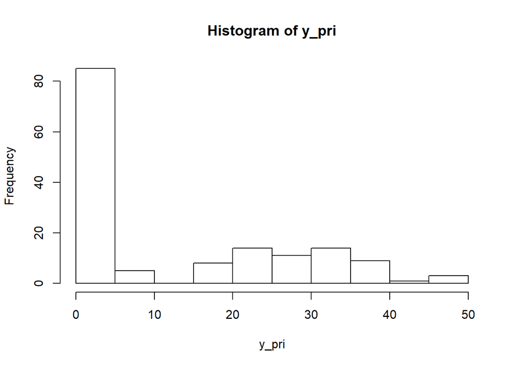

```r
lam_pri <- lam_pri[1:5]
y_pri <- rpois(150, lambda = rep(lam_pri, each=30))

hist(y_pri)
```

## Create Jags Model

```r
mod1_string <- "model{
  for(i in 1:length(chips)){
    chips[i] ~ dpois(lam[location[i]])
  }

  for(j in 1:max(location)){
    lam[j] ~ dgamma(alpha, beta)
  }

  mu ~ dgamma(2.0, 1.0/5.0)
  sig ~ dexp(1.0)

  alpha = mu^2/sig^2
  beta = mu / sig^2
}"

data1_jags <- as.list(dat)

params1 <- c("lam", "mu", "sig")

mod1 <- jags.model(textConnection(mod1_string), data=data1_jags, n.chains=3)
```

[figure not shown]

[figure not shown]

```r
update(mod1, 1e3)

mod1_sim <- coda.samples(model=mod1, variable.names=params1, n.iter=5e3)
mod1_csim <- as.mcmc(do.call(rbind, mod1_sim))

plot(mod1_sim, ask=TRUE)
```

```r
dic1 <- dic.samples(mod1, 1e3)

dic1
```

```
## Mean deviance:  783.7
## penalty 4.876
## Penalized deviance: 788.6
```

## Model Checking

Now that we have our model, we want to evaluate the residuals.

```r
pm_params <- colMeans(mod1_csim)

pm_params
```

```
##    lam[1]    lam[2]    lam[3]    lam[4]    lam[5]        mu       sig
##  9.280709  6.216966  9.526669  8.946747 11.767316  9.088074  2.072860
```

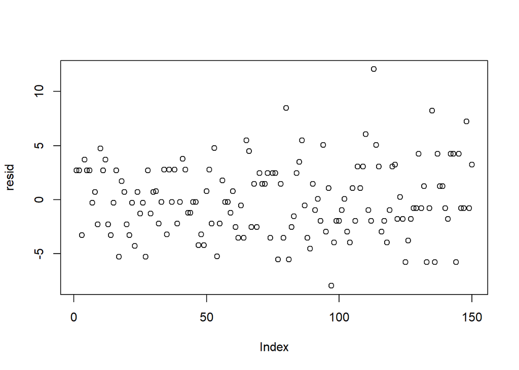

```r
yhat <- rep(pm_params[1:5], each=30)
resid <- dat$chips - yhat

plot(resid)
```

These residuals look good, no patterns are seen here.

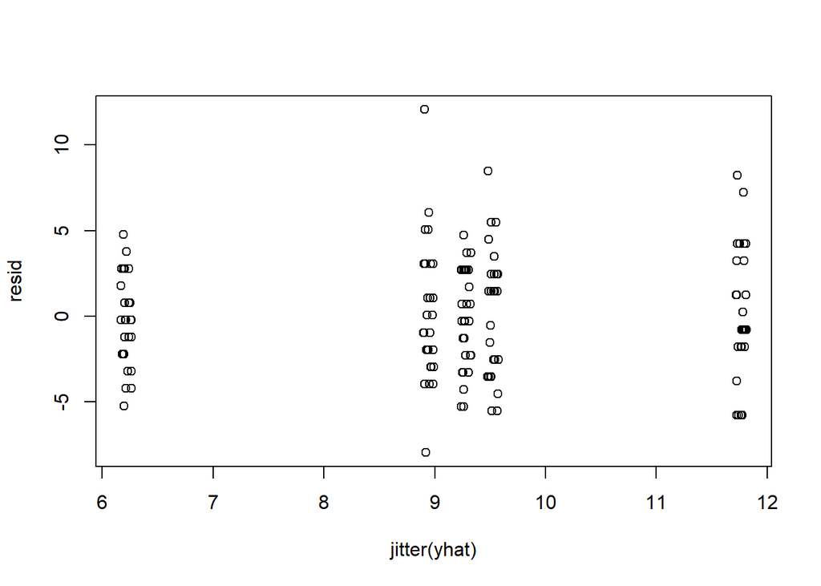

```r
plot(jitter(yhat), resid)
```

The same for these ones. We might think that the variance is increasing as the prediction increases, but that’s becuase in a poisson model the variance is proportional to the mean.

One thing that we can check is that for each strata the variance is similar to the predicted values.

```r
var(resid[yhat > 11])
```

```
## [1] 13.72414
```

## Posterior Predictive Simulations

Analogous to the prior predictive simulations, we can take draws from our posterior distributions to do a similar kind of analysis.

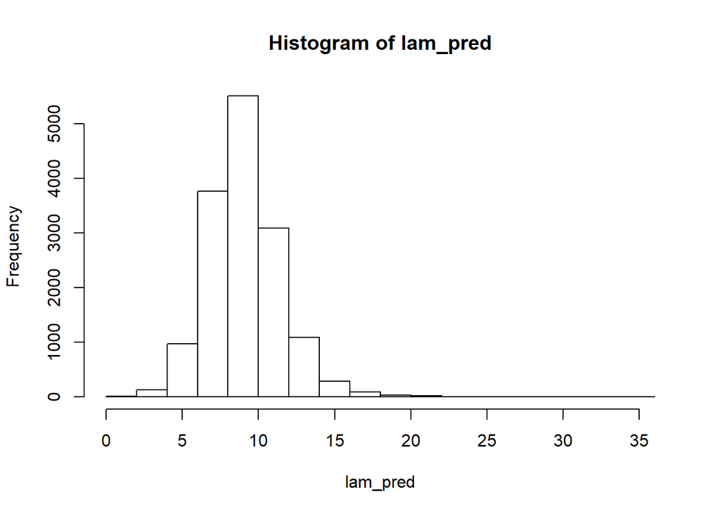

```r
n_sim <- nrow(mod1_csim)

post_alpha <- mod1_csim[,"mu"]^2/mod1_csim[,"sig"]^2
post_beta <-  mod1_csim[,"mu"]/mod1_csim[,"sig"]^2

lam_pred <- rgamma(n_sim, shape=post_alpha, rate=post_beta)

hist(lam_pred)
```

We can even get the probability that the lamda is higher than some value.

```r
mean(lam_pred > 15)
```

```
## [1] 0.01766667
```

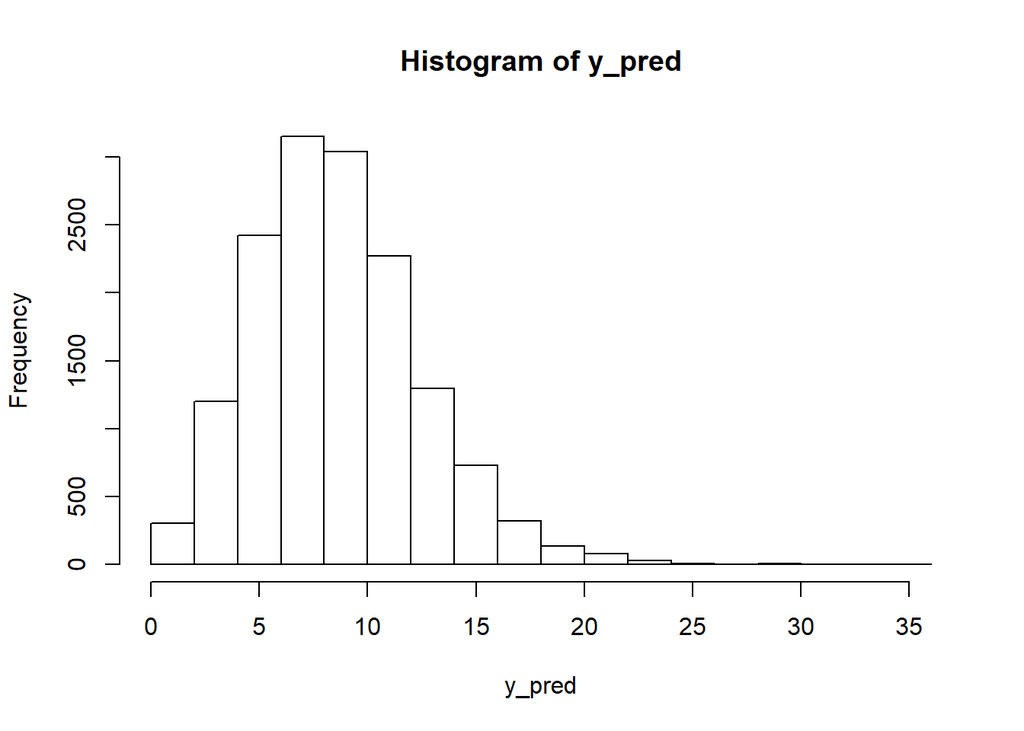

```r
y_pred <- rpois(n_sim, lambda = lam_pred)

hist(y_pred)
```

```r
mean(y_pred > 15)
```

```
## [1] 0.05906667
```

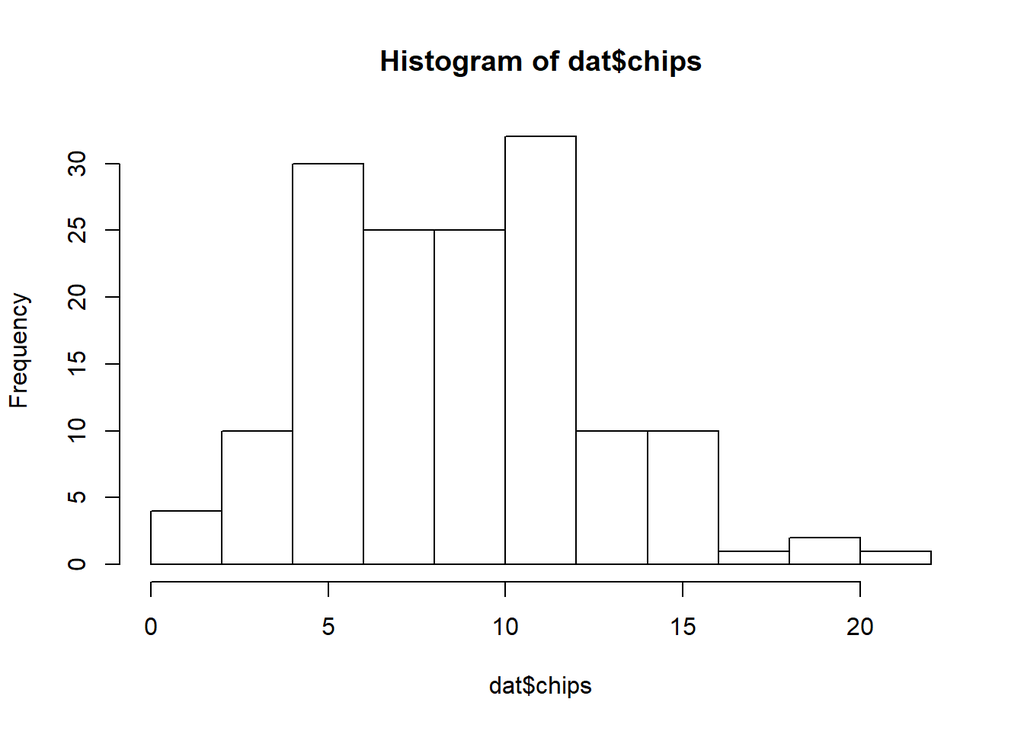

```r
hist(dat$chips)
```

We can see that our distribution and our posterior distribution are pretty similar.

We can answer other questions too "what is the posterior prob that the next cookie produced at loc. 1 has fewer than 7 chips?

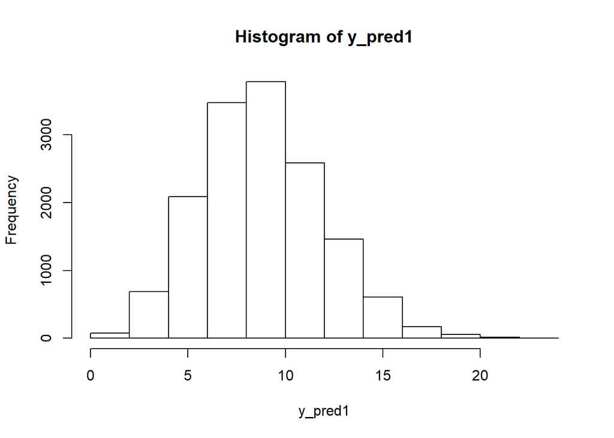

```r
y_pred1 <- rpois(n_sim, lambda = mod1_csim[,"lam[1]"])

hist(y_pred1)
```

```r
mean(y_pred1 < 7)
```

```
## [1] 0.1899333
```